# playstore analysis

```python
import numpy as np
import pandas as pd
import matplotlib.pyplot as plt
import seaborn as sns
from sklearn.preprocessing import Imputer

%matplotlib inline
```

## 1. Business Understanding

a) How apps are distributed among categories?  
b) What are the most popular categories in the play store?  
c) How this changed over past few years?  
d) What are the top installed vs. Rated Freemium/Premium apps?  
e) What’s the average Premium App price?

## 2. Data Understanding

```python
#Dataset used for analysis can be found here: https://www.kaggle.com/lava18/google-play-store-apps
#Blog article:https://medium.com/@mohammed0hamdan/322767a8d154

#load the dataset
df = pd.read_csv('./googleplaystore.csv')
```

```python
df.head()
```

|  | App | Category | Rating | Reviews | Size | Installs | Type | Price | Content Rating | Genres | Last Updated | Current Ver | Android Ver |
| --- | --- | --- | --- | --- | --- | --- | --- | --- | --- | --- | --- | --- | --- |
| 0 | Photo Editor & Candy Camera & Grid & ScrapBook | ART_AND_DESIGN | 4.1 | 159 | 19M | 10,000+ | Free | 0 | Everyone | Art & Design | January 7, 2018 | 1.0.0 | 4.0.3 and up |
| 1 | Coloring book moana | ART_AND_DESIGN | 3.9 | 967 | 14M | 500,000+ | Free | 0 | Everyone | Art & Design;Pretend Play | January 15, 2018 | 2.0.0 | 4.0.3 and up |
| 2 | U Launcher Lite – FREE Live Cool Themes, Hide ... | ART_AND_DESIGN | 4.7 | 87510 | 8.7M | 5,000,000+ | Free | 0 | Everyone | Art & Design | August 1, 2018 | 1.2.4 | 4.0.3 and up |
| 3 | Sketch - Draw & Paint | ART_AND_DESIGN | 4.5 | 215644 | 25M | 50,000,000+ | Free | 0 | Teen | Art & Design | June 8, 2018 | Varies with device | 4.2 and up |
| 4 | Pixel Draw - Number Art Coloring Book | ART_AND_DESIGN | 4.3 | 967 | 2.8M | 100,000+ | Free | 0 | Everyone | Art & Design;Creativity | June 20, 2018 | 1.1 | 4.4 and up |

```python
#num of rows and columns
print(df.shape)
```

```
(10841, 13)
```

```python
#info about each column
df.info()
```

```
<class 'pandas.core.frame.DataFrame'>
RangeIndex: 10841 entries, 0 to 10840
Data columns (total 13 columns):
App               10841 non-null object
Category          10841 non-null object
Rating            9367 non-null float64
Reviews           10841 non-null object
Size              10841 non-null object
Installs          10841 non-null object
Type              10840 non-null object
Price             10841 non-null object
Content Rating    10840 non-null object
Genres            10841 non-null object
Last Updated      10841 non-null object
Current Ver       10833 non-null object
Android Ver       10838 non-null object
dtypes: float64(1), object(12)
memory usage: 1.1+ MB
```

```python
# Check null/missing values by column
print(df.isnull().sum().sort_values(ascending=False))
```

```
Rating            1474
Current Ver          8
Android Ver          3
Content Rating       1
Type                 1
Last Updated         0
Genres               0
Price                0
Installs             0
Size                 0
Reviews              0
Category             0
App                  0
dtype: int64
```

```python
# % of missing values for each column
df.isnull().mean()*100
```

```
App                0.000000
Category           0.000000
Rating            13.596532
Reviews            0.000000
Size               0.000000
Installs           0.000000
Type               0.009224
Price              0.000000
Content Rating     0.009224
Genres             0.000000
Last Updated       0.000000
Current Ver        0.073794
Android Ver        0.027673
dtype: float64
```

```python
#examine columns data types
df.dtypes

#Review, Size, Installs, Price and Last updated are not categorical and data type shouldn't be object,
#we need to convert these columns to their corresponding types
```

```
App                object
Category           object
Rating            float64
Reviews            object
Size               object
Installs           object
Type               object
Price              object
Content Rating     object
Genres             object
Last Updated       object
Current Ver        object
Android Ver        object
dtype: object
```

```python
#take a look at columns values
df.Size.unique()
```

```
array(['19M', '14M', '8.7M', '25M', '2.8M', '5.6M', '29M', '33M', '3.1M',
       '28M', '12M', '20M', '21M', '37M', '2.7M', '5.5M', '17M', '39M',
       '31M', '4.2M', '7.0M', '23M', '6.0M', '6.1M', '4.6M', '9.2M',
       '5.2M', '11M', '24M', 'Varies with device', '9.4M', '15M', '10M',
       '1.2M', '26M', '8.0M', '7.9M', '56M', '57M', '35M', '54M', '201k',
       '3.6M', '5.7M', '8.6M', '2.4M', '27M', '2.5M', '16M', '3.4M',
       '8.9M', '3.9M', '2.9M', '38M', '32M', '5.4M', '18M', '1.1M',
       '2.2M', '4.5M', '9.8M', '52M', '9.0M', '6.7M', '30M', '2.6M',
       '7.1M', '3.7M', '22M', '7.4M', '6.4M', '3.2M', '8.2M', '9.9M',
       '4.9M', '9.5M', '5.0M', '5.9M', '13M', '73M', '6.8M', '3.5M',
       '4.0M', '2.3M', '7.2M', '2.1M', '42M', '7.3M', '9.1M', '55M',
       '23k', '6.5M', '1.5M', '7.5M', '51M', '41M', '48M', '8.5M', '46M',
       '8.3M', '4.3M', '4.7M', '3.3M', '40M', '7.8M', '8.8M', '6.6M',
       '5.1M', '61M', '66M', '79k', '8.4M', '118k', '44M', '695k', '1.6M',
       '6.2M', '18k', '53M', '1.4M', '3.0M', '5.8M', '3.8M', '9.6M',
       '45M', '63M', '49M', '77M', '4.4M', '4.8M', '70M', '6.9M', '9.3M',
       '10.0M', '8.1M', '36M', '84M', '97M', '2.0M', '1.9M', '1.8M',
       '5.3M', '47M', '556k', '526k', '76M', '7.6M', '59M', '9.7M', '78M',
       '72M', '43M', '7.7M', '6.3M', '334k', '34M', '93M', '65M', '79M',
       '100M', '58M', '50M', '68M', '64M', '67M', '60M', '94M', '232k',
       '99M', '624k', '95M', '8.5k', '41k', '292k', '11k', '80M', '1.7M',
       '74M', '62M', '69M', '75M', '98M', '85M', '82M', '96M', '87M',
       '71M', '86M', '91M', '81M', '92M', '83M', '88M', '704k', '862k',
       '899k', '378k', '266k', '375k', '1.3M', '975k', '980k', '4.1M',
       '89M', '696k', '544k', '525k', '920k', '779k', '853k', '720k',
       '713k', '772k', '318k', '58k', '241k', '196k', '857k', '51k',
       '953k', '865k', '251k', '930k', '540k', '313k', '746k', '203k',
       '26k', '314k', '239k', '371k', '220k', '730k', '756k', '91k',
       '293k', '17k', '74k', '14k', '317k', '78k', '924k', '902k', '818k',
       '81k', '939k', '169k', '45k', '475k', '965k', '90M', '545k', '61k',
       '283k', '655k', '714k', '93k', '872k', '121k', '322k', '1.0M',
       '976k', '172k', '238k', '549k', '206k', '954k', '444k', '717k',
       '210k', '609k', '308k', '705k', '306k', '904k', '473k', '175k',
       '350k', '383k', '454k', '421k', '70k', '812k', '442k', '842k',
       '417k', '412k', '459k', '478k', '335k', '782k', '721k', '430k',
       '429k', '192k', '200k', '460k', '728k', '496k', '816k', '414k',
       '506k', '887k', '613k', '243k', '569k', '778k', '683k', '592k',
       '319k', '186k', '840k', '647k', '191k', '373k', '437k', '598k',
       '716k', '585k', '982k', '222k', '219k', '55k', '948k', '323k',
       '691k', '511k', '951k', '963k', '25k', '554k', '351k', '27k',
       '82k', '208k', '913k', '514k', '551k', '29k', '103k', '898k',
       '743k', '116k', '153k', '209k', '353k', '499k', '173k', '597k',
       '809k', '122k', '411k', '400k', '801k', '787k', '237k', '50k',
       '643k', '986k', '97k', '516k', '837k', '780k', '961k', '269k',
       '20k', '498k', '600k', '749k', '642k', '881k', '72k', '656k',
       '601k', '221k', '228k', '108k', '940k', '176k', '33k', '663k',
       '34k', '942k', '259k', '164k', '458k', '245k', '629k', '28k',
       '288k', '775k', '785k', '636k', '916k', '994k', '309k', '485k',
       '914k', '903k', '608k', '500k', '54k', '562k', '847k', '957k',
       '688k', '811k', '270k', '48k', '329k', '523k', '921k', '874k',
       '981k', '784k', '280k', '24k', '518k', '754k', '892k', '154k',
       '860k', '364k', '387k', '626k', '161k', '879k', '39k', '970k',
       '170k', '141k', '160k', '144k', '143k', '190k', '376k', '193k',
       '246k', '73k', '658k', '992k', '253k', '420k', '404k', '1,000+',
       '470k', '226k', '240k', '89k', '234k', '257k', '861k', '467k',
       '157k', '44k', '676k', '67k', '552k', '885k', '1020k', '582k',
       '619k'], dtype=object)
```

> Size: Here we need to do some data processing, specifically remove letters k and M and convert numbers to same unit also we need handle rows with values like 'Varies with device'

```python
#explore price unique values
df.Price.unique()
```

```
array(['0', '$4.99', '$3.99', '$6.99', '$1.49', '$2.99', '$7.99', '$5.99',
       '$3.49', '$1.99', '$9.99', '$7.49', '$0.99', '$9.00', '$5.49',
       '$10.00', '$24.99', '$11.99', '$79.99', '$16.99', '$14.99',
       '$1.00', '$29.99', '$12.99', '$2.49', '$10.99', '$1.50', '$19.99',
       '$15.99', '$33.99', '$74.99', '$39.99', '$3.95', '$4.49', '$1.70',
       '$8.99', '$2.00', '$3.88', '$25.99', '$399.99', '$17.99',
       '$400.00', '$3.02', '$1.76', '$4.84', '$4.77', '$1.61', '$2.50',
       '$1.59', '$6.49', '$1.29', '$5.00', '$13.99', '$299.99', '$379.99',
       '$37.99', '$18.99', '$389.99', '$19.90', '$8.49', '$1.75',
       '$14.00', '$4.85', '$46.99', '$109.99', '$154.99', '$3.08',
       '$2.59', '$4.80', '$1.96', '$19.40', '$3.90', '$4.59', '$15.46',
       '$3.04', '$4.29', '$2.60', '$3.28', '$4.60', '$28.99', '$2.95',
       '$2.90', '$1.97', '$200.00', '$89.99', '$2.56', '$30.99', '$3.61',
       '$394.99', '$1.26', 'Everyone', '$1.20', '$1.04'], dtype=object)
```

> Price : We need to convert data type to float and remove the $ sign

```python
df.Installs.unique()
```

```
array(['10,000+', '500,000+', '5,000,000+', '50,000,000+', '100,000+',
       '50,000+', '1,000,000+', '10,000,000+', '5,000+', '100,000,000+',
       '1,000,000,000+', '1,000+', '500,000,000+', '50+', '100+', '500+',
       '10+', '1+', '5+', '0+', '0', 'Free'], dtype=object)
```

> Installs: convert to integer, remove , and + signs

```python
#check reviews values
df.Reviews.unique()
```

```
array(['159', '967', '87510', ..., '603', '1195', '398307'], dtype=object)
```

> Reviews: convert to integer

```python
#examine last updated values
df['Last Updated'].unique()
```

```
array(['January 7, 2018', 'January 15, 2018', 'August 1, 2018', ...,
       'January 20, 2014', 'February 16, 2014', 'March 23, 2014'],
      dtype=object)
```

```python
df['App'].value_counts()
```

```
ROBLOX                                                9
CBS Sports App - Scores, News, Stats & Watch Live     8
Candy Crush Saga                                      7
Duolingo: Learn Languages Free                        7
8 Ball Pool                                           7
ESPN                                                  7
Bowmasters                                            6
Temple Run 2                                          6
Helix Jump                                            6
Zombie Catchers                                       6
slither.io                                            6
Bleacher Report: sports news, scores, & highlights    6
Bubble Shooter                                        6
Sniper 3D Gun Shooter: Free Shooting Games - FPS      6
Subway Surfers                                        6
Nick                                                  6
Calorie Counter - MyFitnessPal                        5
Plants vs. Zombies FREE                               5
TripAdvisor Hotels Flights Restaurants Attractions    5
MLB At Bat                                            5
Wish - Shopping Made Fun                              5
eBay: Buy & Sell this Summer - Discover Deals Now!    5
theScore: Live Sports Scores, News, Stats & Videos    5
Flow Free                                             5
Yahoo Fantasy Sports - #1 Rated Fantasy App           5
Farm Heroes Saga                                      5
Netflix                                               5
Skyscanner                                            5
Angry Birds Classic                                   5
Granny                                                5
                                                     ..
Zynga Poker – Texas Holdem                            1
The Vietnam Story - Fun Stories                       1
ER Surgery Simulator                                  1
Can I pack that? - DG App                             1
Body scanner (prank)                                  1
Touch Racing 2 - Mini RC Race                         1
Bedouin Rivals                                        1
Funny Quotes Free                                     1
Hospital ER Emergency Heart Surgery: Doctor Games     1
BMX Boy                                               1
Township                                              1
Santa Fe New Mexican e-Edition                        1
MyMo by GSB                                           1
Photo Lock App - Hide Pictures & Videos               1
EMI, FD, RD - Bank Calculator                         1
WiFi Access Point (hotspot)                           1
Check Vehicle Tax                                     1
Florida Storms                                        1
BMX Boy Bike Stunt Rider Game                         1
CA DMV                                                1
GPS Traffic Speedcam Route Planner by ViaMichelin     1
ASUS PixelMaster Camera                               1
DT Baby Cam                                           1
Partymasters - Fun Idle Game                          1
Real Estate by Movoto                                 1
CP Brown English-Telugu Dictionary                    1
B-17 Flying Fortress WWII LWP                         1
AU Mobile Indonesia                                   1
The Guardian                                          1
Noticias FC Barcelona                                 1
Name: App, Length: 9660, dtype: int64
```

> App has duplicate rows

```python
#examine one of the duplicate apps, turns out to be the exact same information, even for the version
df[df.App == 'ROBLOX']
```

|  | App | Category | Rating | Reviews | Size | Installs | Type | Price | Content Rating | Genres | Last Updated | Current Ver | Android Ver |
| --- | --- | --- | --- | --- | --- | --- | --- | --- | --- | --- | --- | --- | --- |
| 1653 | ROBLOX | GAME | 4.5 | 4447388 | 67M | 100,000,000+ | Free | 0 | Everyone 10+ | Adventure;Action & Adventure | July 31, 2018 | 2.347.225742 | 4.1 and up |
| 1701 | ROBLOX | GAME | 4.5 | 4447346 | 67M | 100,000,000+ | Free | 0 | Everyone 10+ | Adventure;Action & Adventure | July 31, 2018 | 2.347.225742 | 4.1 and up |
| 1748 | ROBLOX | GAME | 4.5 | 4448791 | 67M | 100,000,000+ | Free | 0 | Everyone 10+ | Adventure;Action & Adventure | July 31, 2018 | 2.347.225742 | 4.1 and up |
| 1841 | ROBLOX | GAME | 4.5 | 4449882 | 67M | 100,000,000+ | Free | 0 | Everyone 10+ | Adventure;Action & Adventure | July 31, 2018 | 2.347.225742 | 4.1 and up |
| 1870 | ROBLOX | GAME | 4.5 | 4449910 | 67M | 100,000,000+ | Free | 0 | Everyone 10+ | Adventure;Action & Adventure | July 31, 2018 | 2.347.225742 | 4.1 and up |
| 2016 | ROBLOX | FAMILY | 4.5 | 4449910 | 67M | 100,000,000+ | Free | 0 | Everyone 10+ | Adventure;Action & Adventure | July 31, 2018 | 2.347.225742 | 4.1 and up |
| 2088 | ROBLOX | FAMILY | 4.5 | 4450855 | 67M | 100,000,000+ | Free | 0 | Everyone 10+ | Adventure;Action & Adventure | July 31, 2018 | 2.347.225742 | 4.1 and up |
| 2206 | ROBLOX | FAMILY | 4.5 | 4450890 | 67M | 100,000,000+ | Free | 0 | Everyone 10+ | Adventure;Action & Adventure | July 31, 2018 | 2.347.225742 | 4.1 and up |
| 4527 | ROBLOX | FAMILY | 4.5 | 4443407 | 67M | 100,000,000+ | Free | 0 | Everyone 10+ | Adventure;Action & Adventure | July 31, 2018 | 2.347.225742 | 4.1 and up |

> App: Get rid of duplicate apps

## 3. Prepare Data

Before delving into data analysis, we need to prepare our data by performing the below steps

- Handle missing values
- Convert columns to their corresponding data types
- Drop not needed columns

> Here I'm dropping missing values for columns (Type, Content Rating, Current Ver, and Android Ver), since these constitute a very small percentage of the dataset < 0.1% each.

```python
#Handling missing values
df.dropna(inplace=True,subset=['Type','Content Rating','Current Ver','Android Ver'])
```

```python
#make sure only Rating column has missing values
df.isnull().mean()
```

```
App               0.000000
Category          0.000000
Rating            0.135654
Reviews           0.000000
Size              0.000000
Installs          0.000000
Type              0.000000
Price             0.000000
Content Rating    0.000000
Genres            0.000000
Last Updated      0.000000
Current Ver       0.000000
Android Ver       0.000000
dtype: float64
```

```python
#Check missing Rating rows
df[df['Rating'].isnull()==True]
```

|  | App | Category | Rating | Reviews | Size | Installs | Type | Price | Content Rating | Genres | Last Updated | Current Ver | Android Ver |
| --- | --- | --- | --- | --- | --- | --- | --- | --- | --- | --- | --- | --- | --- |
| 23 | Mcqueen Coloring pages | ART_AND_DESIGN | NaN | 61 | 7.0M | 100,000+ | Free | 0 | Everyone | Art & Design;Action & Adventure | March 7, 2018 | 1.0.0 | 4.1 and up |
| 113 | Wrinkles and rejuvenation | BEAUTY | NaN | 182 | 5.7M | 100,000+ | Free | 0 | Everyone 10+ | Beauty | September 20, 2017 | 8.0 | 3.0 and up |
| 123 | Manicure - nail design | BEAUTY | NaN | 119 | 3.7M | 50,000+ | Free | 0 | Everyone | Beauty | July 23, 2018 | 1.3 | 4.1 and up |
| 126 | Skin Care and Natural Beauty | BEAUTY | NaN | 654 | 7.4M | 100,000+ | Free | 0 | Teen | Beauty | July 17, 2018 | 1.15 | 4.1 and up |
| 129 | Secrets of beauty, youth and health | BEAUTY | NaN | 77 | 2.9M | 10,000+ | Free | 0 | Mature 17+ | Beauty | August 8, 2017 | 2.0 | 2.3 and up |
| 130 | Recipes and tips for losing weight | BEAUTY | NaN | 35 | 3.1M | 10,000+ | Free | 0 | Everyone 10+ | Beauty | December 11, 2017 | 2.0 | 3.0 and up |
| 134 | Lady adviser (beauty, health) | BEAUTY | NaN | 30 | 9.9M | 10,000+ | Free | 0 | Mature 17+ | Beauty | January 24, 2018 | 3.0 | 3.0 and up |
| 163 | Anonymous caller detection | BOOKS_AND_REFERENCE | NaN | 161 | 2.7M | 10,000+ | Free | 0 | Everyone | Books & Reference | July 13, 2018 | 1.0 | 2.3 and up |
| 180 | SH-02J Owner's Manual (Android 8.0) | BOOKS_AND_REFERENCE | NaN | 2 | 7.2M | 50,000+ | Free | 0 | Everyone | Books & Reference | June 15, 2018 | 3.0 | 6.0 and up |
| 185 | URBANO V 02 instruction manual | BOOKS_AND_REFERENCE | NaN | 114 | 7.3M | 100,000+ | Free | 0 | Everyone | Books & Reference | August 7, 2015 | 1.1 | 5.1 and up |
| 227 | Y! Mobile menu | BUSINESS | NaN | 9 | 1.2M | 100,000+ | Free | 0 | Everyone | Business | April 9, 2018 | 1.0.5 | 6.0 and up |
| 321 | 【Ranobbe complete free】 Novelba - Free app tha... | COMICS | NaN | 1330 | 22M | 50,000+ | Free | 0 | Everyone | Comics | July 3, 2018 | 6.1.1 | 4.2 and up |
| 478 | Truth or Dare Pro | DATING | NaN | 0 | 20M | 50+ | Paid | $1.49 | Teen | Dating | September 1, 2017 | 1.0 | 4.0 and up |
| 479 | Private Dating, Hide App- Blue for PrivacyHider | DATING | NaN | 0 | 18k | 100+ | Paid | $2.99 | Everyone | Dating | July 25, 2017 | 1.0.1 | 4.0 and up |
| 480 | Ad Blocker for SayHi | DATING | NaN | 4 | 1.2M | 100+ | Paid | $3.99 | Teen | Dating | August 2, 2018 | 1.2 | 4.0.3 and up |
| 610 | Random Video Chat | DATING | NaN | 3 | 16M | 1,000+ | Free | 0 | Mature 17+ | Dating | July 15, 2018 | 4.20 | 4.0.3 and up |
| 613 | Random Video Chat App With Strangers | DATING | NaN | 3 | 4.8M | 1,000+ | Free | 0 | Mature 17+ | Dating | July 17, 2018 | 1. | 4.0 and up |
| 617 | Meet With Strangers: Video Chat & Dating | DATING | NaN | 2 | 3.7M | 500+ | Free | 0 | Mature 17+ | Dating | July 16, 2018 | 1. | 4.0 and up |
| 620 | Ost. Zombies Cast - New Music and Lyrics | DATING | NaN | 1 | 4.6M | 100+ | Free | 0 | Teen | Dating | July 20, 2018 | 1.0 | 4.0.3 and up |
| 621 | Dating White Girls | DATING | NaN | 0 | 3.6M | 50+ | Free | 0 | Mature 17+ | Dating | July 20, 2018 | 1.0 | 4.0 and up |
| 623 | Geeks Dating | DATING | NaN | 0 | 13M | 50+ | Free | 0 | Mature 17+ | Dating | July 10, 2018 | 1.0 | 4.1 and up |
| 624 | Live chat - free video chat | DATING | NaN | 1 | 8.7M | 500+ | Free | 0 | Mature 17+ | Dating | July 23, 2018 | 3.52 | 4.0.3 and up |
| 626 | Fishing Brain & Boating Maps Marine | DATING | NaN | 3 | 6.9M | 500+ | Free | 0 | Everyone | Dating | July 23, 2018 | 1.0 | 4.0.3 and up |
| 627 | CAM5678 Video Chat | DATING | NaN | 0 | 39M | 500+ | Free | 0 | Mature 17+ | Dating | July 13, 2018 | 5.5.8 | 4.0.3 and up |
| 628 | Video chat live advices | DATING | NaN | 0 | 8.0M | 100+ | Free | 0 | Everyone | Dating | July 10, 2018 | 1.0 | 3.0 and up |
| 629 | chat live chat | DATING | NaN | 24 | 3.9M | 1,000+ | Free | 0 | Mature 17+ | Dating | July 26, 2018 | 1.0 | 4.0 and up |
| 630 | Pet Lovers Dating | DATING | NaN | 0 | 14M | 10+ | Free | 0 | Mature 17+ | Dating | July 9, 2018 | 1.0 | 4.1 and up |
| 631 | Friend Find: free chat + flirt dating app | DATING | NaN | 23 | 11M | 100+ | Free | 0 | Mature 17+ | Dating | July 31, 2018 | 1.0 | 4.4 and up |
| 632 | Latin Dating | DATING | NaN | 0 | 13M | 10+ | Free | 0 | Mature 17+ | Dating | July 9, 2018 | 1.0 | 4.1 and up |
| 635 | Wifi Mingle | DATING | NaN | 0 | 10.0M | 10+ | Free | 0 | Everyone | Dating | July 27, 2018 | 1.3 | 4.4 and up |
| ... | ... | ... | ... | ... | ... | ... | ... | ... | ... | ... | ... | ... | ... |
| 10746 | FP Opgaver | TOOLS | NaN | 9 | 61M | 1,000+ | Free | 0 | Everyone | Tools | May 31, 2018 | 1.9 | 4.0.3 and up |
| 10748 | FP Live | COMMUNICATION | NaN | 0 | 3.3M | 10+ | Free | 0 | Teen | Communication | November 3, 2017 | 1.2.4 | 4.2 and up |
| 10751 | FP Market | FAMILY | NaN | 24 | 44k | 1,000+ | Free | 0 | Everyone | Education | June 17, 2012 | 1.0 | 1.6 and up |
| 10759 | FP NFC Rewrite | TOOLS | NaN | 17 | 67k | 1,000+ | Free | 0 | Everyone | Tools | January 29, 2016 | 1.1 | 4.0 and up |
| 10761 | Greek Bible FP (Audio) | BOOKS_AND_REFERENCE | NaN | 5 | 8.0M | 1,000+ | Free | 0 | Everyone | Books & Reference | August 29, 2016 | 1.0.0 | 4.0.3 and up |
| 10762 | The FP Shield | NEWS_AND_MAGAZINES | NaN | 0 | 11M | 10+ | Free | 0 | Everyone | News & Magazines | February 1, 2018 | 1.1.0 | 4.4 and up |
| 10764 | FP Transportation | AUTO_AND_VEHICLES | NaN | 1 | 885k | 1+ | Free | 0 | Everyone | Auto & Vehicles | March 9, 2018 | 10.0.0 | 4.0 and up |
| 10769 | FQ Magazine | LIFESTYLE | NaN | 1 | 12M | 100+ | Free | 0 | Everyone | Lifestyle | December 12, 2016 | 1.0 | 4.1 and up |
| 10772 | FQ Load Board for Transporters | BUSINESS | NaN | 0 | 3.9M | 100+ | Free | 0 | Everyone | Business | February 16, 2018 | 1.1.3 | 5.0 and up |
| 10773 | FQ India | LIFESTYLE | NaN | 0 | 8.9M | 10+ | Free | 0 | Everyone | Lifestyle | July 31, 2018 | 7.2.2 | 4.1 and up |
| 10774 | Miss FQ | NEWS_AND_MAGAZINES | NaN | 0 | 36M | 10+ | Free | 0 | Everyone | News & Magazines | April 5, 2018 | 3.8 | 4.4 and up |
| 10775 | FQ - Football Quiz | SPORTS | NaN | 1 | 9.0M | 1+ | Free | 0 | Everyone | Sports | May 29, 2018 | 1.0 | 5.0 and up |
| 10788 | Fountain Live Wallpaper HD – Dubai Wallpaper 3D | PERSONALIZATION | NaN | 1 | 20M | 500+ | Free | 0 | Everyone | Personalization | April 13, 2018 | 1.0 | 4.1 and up |
| 10794 | PopStar | FAMILY | NaN | 13 | 5.7M | 1,000+ | Free | 0 | Everyone | Casual | January 3, 2018 | 1.6 | 4.3 and up |
| 10798 | Word Search Tab 1 FR | FAMILY | NaN | 0 | 1020k | 50+ | Paid | $1.04 | Everyone | Puzzle | February 6, 2012 | 1.1 | 3.0 and up |
| 10806 | SnakeBite911 FR | MEDICAL | NaN | 1 | 42M | 500+ | Free | 0 | Everyone | Medical | October 9, 2017 | 1.2 | 4.1 and up |
| 10807 | My FR App | TOOLS | NaN | 2 | 4.2M | 100+ | Free | 0 | Everyone | Tools | April 9, 2018 | 1.283.0037 | 2.3.3 and up |
| 10808 | lesparticuliers.fr | LIFESTYLE | NaN | 96 | 1.0M | 50,000+ | Free | 0 | Everyone | Lifestyle | November 25, 2014 | 1.5 | 2.3 and up |
| 10811 | FR Plus 1.6 | AUTO_AND_VEHICLES | NaN | 4 | 3.9M | 100+ | Free | 0 | Everyone | Auto & Vehicles | July 24, 2018 | 1.3.6 | 4.4W and up |
| 10813 | DICT.fr Mobile | BUSINESS | NaN | 20 | 2.7M | 10,000+ | Free | 0 | Everyone | Business | July 17, 2018 | 2.1.10 | 4.1 and up |
| 10816 | FieldBi FR Offline | BUSINESS | NaN | 2 | 6.8M | 100+ | Free | 0 | Everyone | Business | August 6, 2018 | 2.1.8 | 4.1 and up |
| 10818 | Gold Quote - Gold.fr | FINANCE | NaN | 96 | 1.5M | 10,000+ | Free | 0 | Everyone | Finance | May 19, 2016 | 2.3 | 2.2 and up |
| 10821 | Poop FR | FAMILY | NaN | 6 | 2.5M | 50+ | Free | 0 | Everyone | Entertainment | May 29, 2018 | 1.0 | 4.0.3 and up |
| 10822 | PLMGSS FR | PRODUCTIVITY | NaN | 0 | 3.1M | 10+ | Free | 0 | Everyone | Productivity | December 1, 2017 | 1 | 4.4 and up |
| 10823 | List iptv FR | VIDEO_PLAYERS | NaN | 1 | 2.9M | 100+ | Free | 0 | Everyone | Video Players & Editors | April 22, 2018 | 1.0 | 4.0.3 and up |
| 10824 | Cardio-FR | MEDICAL | NaN | 67 | 82M | 10,000+ | Free | 0 | Everyone | Medical | July 31, 2018 | 2.2.2 | 4.4 and up |
| 10825 | Naruto & Boruto FR | SOCIAL | NaN | 7 | 7.7M | 100+ | Free | 0 | Teen | Social | February 2, 2018 | 1.0 | 4.0 and up |
| 10831 | payermonstationnement.fr | MAPS_AND_NAVIGATION | NaN | 38 | 9.8M | 5,000+ | Free | 0 | Everyone | Maps & Navigation | June 13, 2018 | 2.0.148.0 | 4.0 and up |
| 10835 | FR Forms | BUSINESS | NaN | 0 | 9.6M | 10+ | Free | 0 | Everyone | Business | September 29, 2016 | 1.1.5 | 4.0 and up |
| 10838 | Parkinson Exercices FR | MEDICAL | NaN | 3 | 9.5M | 1,000+ | Free | 0 | Everyone | Medical | January 20, 2017 | 1.0 | 2.2 and up |

1469 rows × 13 columns

> Missing rating does not seem to mean that these app have not received any rating, as we can see many of them have more than 10k downloads. I've decided to fill Rating missing values with the average rating of their correspondent category

```python
df.Rating = df.groupby(['Category'])['Rating'].apply(lambda x: x.fillna(x.mean()))
```

```python
#Check if these all missing values are filled
df[df['Rating'].isnull()==True]
```

|  | App | Category | Rating | Reviews | Size | Installs | Type | Price | Content Rating | Genres | Last Updated | Current Ver | Android Ver |
| --- | --- | --- | --- | --- | --- | --- | --- | --- | --- | --- | --- | --- | --- |

```python
#find out how many time the size equals 'varies with device'
print(len(df[df.Size == 'Varies with device']))
```

```
1694
```

```python
def size_to_float(size):
    """
    Remove M and k from input and converts KB to MB

    Parameter:
    size: string representation of size

    Returns:
    size: float
    """

    if size.endswith('M'):
        return float(size.replace("M","").replace(",",""))
    elif size.endswith('k'):
        return float(size.replace("k","").replace(",",""))/1000
    else:
        return size
```

```python
#Remove k and M from size, convert KB to MB
df['Size'] = df['Size'].apply(size_to_float)

#replace 'varies with device' with nan
df['Size'] = df['Size'].replace('Varies with device',np.nan)
#fill na with the mean of size in each category
df['Size'].fillna(df.groupby('Category')['Size'].mean(),inplace=True)
#check for nan values
df[df.Size == np.nan]
```

|  | App | Category | Rating | Reviews | Size | Installs | Type | Price | Content Rating | Genres | Last Updated | Current Ver | Android Ver |
| --- | --- | --- | --- | --- | --- | --- | --- | --- | --- | --- | --- | --- | --- |

```python
#convert Reviews to int
df.Reviews = df.Reviews.astype(int)
```

```python
# Get rid of + and , in the Installs, then convert it to int
def installs_to_int(install_no):

    """
    Remove + and , signs, then convert it to int

    Parameter:
    install_no: string representation of # of installs

    Returns:
    install_no: int
    """
    return int(install_no.replace("+","").replace(",",""))
```

```python
df['Installs'] = df['Installs'].apply(installs_to_int)
```

```python
def date_to_year(date):
    """
    Returns the year part of a date

    Parameter:
    date: date

    Returns:
    year: int
    """
    return date.year
```

```python
df['Last Updated'] = pd.to_datetime(df['Last Updated'])
#create a new column 'Year' and update it with the year value of the last updated
df['Year'] = df['Last Updated'].apply(date_to_year)
#drop last updated column, I'm only interested in the year
df.drop(['Last Updated'], axis=1,inplace=True)
```

```python
def price_to_float(price):
    """
    Removes $ and , signs, then convert it to float

    Parameter:
    price: string representation of price

    Returns:
    price: float
    """
    return float(price.replace("$","").replace(",",""))
```

```python
#remove $ sign and convert value to float
df['Price'] = df['Price'].apply(price_to_float)
```

```python
# Keeps the last duplicate App and drop the rest
df = df.drop_duplicates(subset=['App'], keep='last')
```

## 4. Answer Questions

#### Question 1: How apps are distributed among categories?

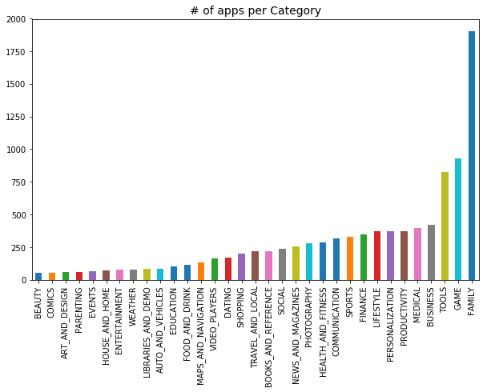

```python
#apps per category
fig, ax = plt.subplots(1, 1, figsize=(10, 6))
df.Category.value_counts().sort_values(ascending=True).plot(kind='bar')
plt.title('# of apps per Category',size = 14)
```

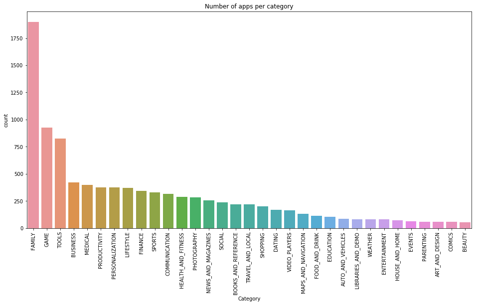

```python
#this time plot using sns
plt.figure(figsize=(16,8))
plt.title('Number of apps per category')

sns.countplot(x='Category',data = df,order=df['Category'].value_counts().index)
plt.xticks(rotation=90)
plt.show()
```

```python
#calculate percentage of top 3 categories
_count = len(df[df.Category == 'FAMILY']) + len(df[df.Category == 'GAME']) + len(df[df.Category == 'TOOLS'])
(_count*100)/df.shape[0]
```

```
37.883499170812605
```

#### What are the most popular categories in the play store?

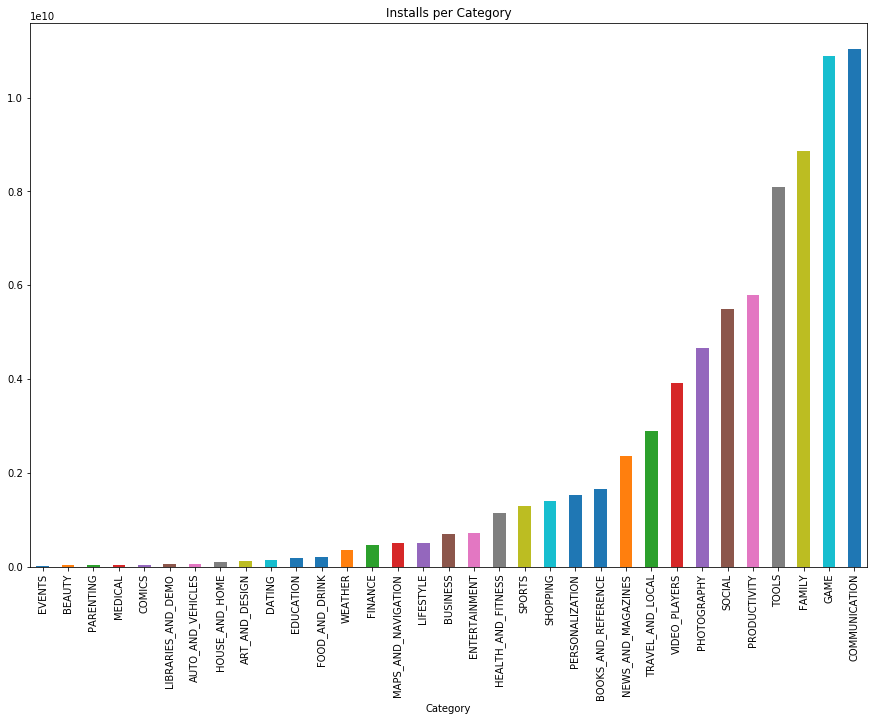

```python
#plot installs per category
fig, ax = plt.subplots(1, 1, figsize=(15, 10))
df.groupby('Category')['Installs'].sum().sort_values(ascending=True).plot(kind='bar')

plt.title('Installs per Category')
```

### How this changed over past few years?

```python
#group data by year
df_grouped_year = df.groupby('Year')
```

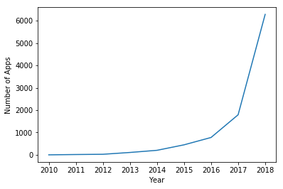

```python
#plot how # apps changes over years
apps_grouped_by_year = df_grouped_year.App.count()


fig=apps_grouped_by_year.plot()
fig.set_xlabel('Year')
fig.set_ylabel('Number of Apps')
```

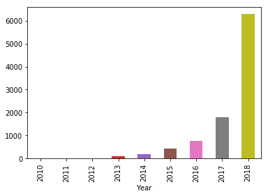

```python
#same information as above but use bars this time
apps_grouped_by_year.sort_values(ascending=True).plot(kind='bar')
```

```python
def plot_appcount(data_frame, year):
    """
    Plots number of apps per gategory for specific year
    Parameters:
      data_frame - Data frame.
      year - The year label
    """
    fig, ax = plt.subplots(1, 1, figsize=(10, 6))
    #data_frame.Category.value_counts().head(10).sort_values(ascending=True).plot(kind='bar')
    plt.title('# Installs per Category in ' + year,size = 14)
    data_frame.groupby('Category')['Installs'].sum().sort_values(ascending=True).plot(kind='bar')#.groups.keys()
```

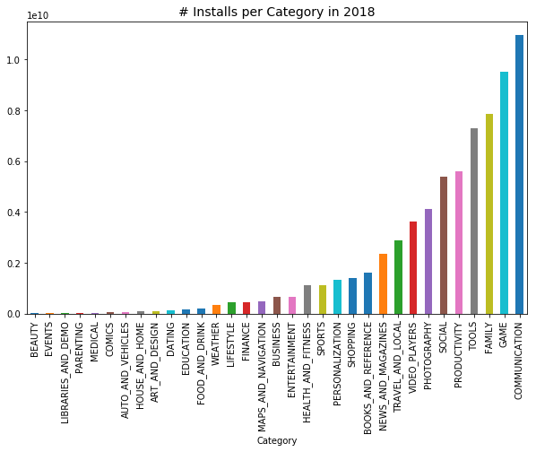

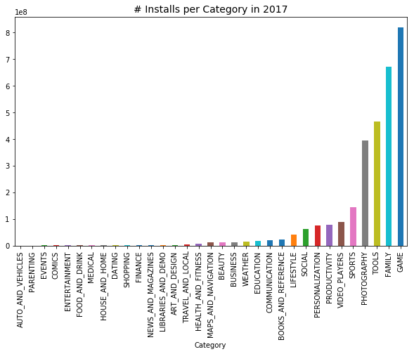

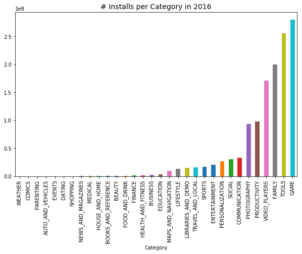

```python
#plot number of installs per category in 2018,2017 and 2016
df_2018 = df[df.Year == 2018]
plot_appcount(df_2018,'2018')

df_2017 = df[df.Year == 2017]
plot_appcount(df_2017,'2017')

df_2016 = df[df.Year == 2016]
plot_appcount(df_2016,'2016')
```

### What are the top installed vs. Rated Freemium/Premium apps?

```python
#counts of unique values for Type
df.Type.value_counts()
```

```
Free    8897
Paid     751
Name: Type, dtype: int64
```

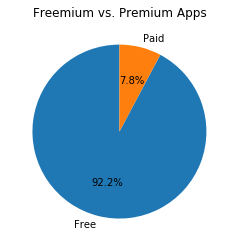

```python
#plot free vs. paid
plt.pie(df.Type.value_counts(),labels=df.Type.unique(), startangle=90, autopct='%.1f%%')
plt.title('Freemium vs. Premium Apps')
plt.show()
```

```python
#free apps
df_free_apps = df[df.Type == 'Free']

#get top 10 rated free apss
df_free_apps.sort_values(by='Rating' , inplace=False , ascending= False).reset_index().head(10)[['App','Category','Rating','Installs']]
```

|  | App | Category | Rating | Installs |
| --- | --- | --- | --- | --- |
| 0 | CJ Gospel Hour | SOCIAL | 5.0 | 100 |
| 1 | CR Tracker for Chests | TOOLS | 5.0 | 50 |
| 2 | BJ Foods | BUSINESS | 5.0 | 10 |
| 3 | EK Bailey Preaching Conference | EVENTS | 5.0 | 500 |
| 4 | DYPSOET | FAMILY | 5.0 | 50 |
| 5 | The Divine Feminine App: the DF App | LIFESTYLE | 5.0 | 1000 |
| 6 | Axe Champs! Wars | GAME | 5.0 | 50 |
| 7 | Master E.K | FAMILY | 5.0 | 1000 |
| 8 | Read it easy for BK | LIFESTYLE | 5.0 | 50 |
| 9 | Startupticker.ch News, Events | NEWS_AND_MAGAZINES | 5.0 | 100 |

```python
df_paid_apps = df[df.Type == 'Paid']
#get top 10 rated paid apps
df_paid_apps[df_paid_apps.Rating == df_paid_apps.Rating.max()].reset_index().head(10)[['App','Price','Category','Rating','Installs']]
```

|  | App | Price | Category | Rating | Installs |
| --- | --- | --- | --- | --- | --- |
| 0 | Super Hearing Secret Voices Recorder PRO | 2.99 | MEDICAL | 5.0 | 100 |
| 1 | FHR 5-Tier 2.0 | 2.99 | MEDICAL | 5.0 | 500 |
| 2 | ADS-B Driver | 1.99 | TOOLS | 5.0 | 100 |
| 3 | P-Home for KLWP | 0.99 | PERSONALIZATION | 5.0 | 100 |
| 4 | Android P Style Icon Pack | 0.99 | PERSONALIZATION | 5.0 | 100 |
| 5 | Easy Hotspot Ad Free | 0.99 | TOOLS | 5.0 | 10 |
| 6 | Hey AJ! It's Saturday! | 3.99 | BOOKS_AND_REFERENCE | 5.0 | 100 |
| 7 | Hey AJ! It's Bedtime! | 4.99 | FAMILY | 5.0 | 10 |
| 8 | AJ Gray Dark Icon Pack | 0.99 | PERSONALIZATION | 5.0 | 10 |
| 9 | AJ Blue Icon Pack | 0.99 | PERSONALIZATION | 5.0 | 50 |

```python
#get top 10 downloaded free apps

df_free_apps.sort_values(by='Installs' , inplace=False , ascending= False).reset_index().head(10)[['App','Category','Rating','Installs']]
```

|  | App | Category | Rating | Installs |
| --- | --- | --- | --- | --- |
| 0 | Google Street View | TRAVEL_AND_LOCAL | 4.2 | 1000000000 |
| 1 | Google | TOOLS | 4.4 | 1000000000 |
| 2 | Google Play Games | FAMILY | 4.3 | 1000000000 |
| 3 | Gmail | COMMUNICATION | 4.3 | 1000000000 |
| 4 | Maps - Navigate & Explore | TRAVEL_AND_LOCAL | 4.3 | 1000000000 |
| 5 | Instagram | SOCIAL | 4.5 | 1000000000 |
| 6 | WhatsApp Messenger | COMMUNICATION | 4.4 | 1000000000 |
| 7 | Google News | NEWS_AND_MAGAZINES | 3.9 | 1000000000 |
| 8 | Messenger – Text and Video Chat for Free | COMMUNICATION | 4.0 | 1000000000 |
| 9 | Subway Surfers | GAME | 4.5 | 1000000000 |

```python
#get top 10 downloaded paid apps

df_paid_apps.sort_values(by='Installs' , inplace=False , ascending= False).reset_index().head(10)[['App','Price','Category','Rating','Installs']]
```

|  | App | Price | Category | Rating | Installs |
| --- | --- | --- | --- | --- | --- |
| 0 | Minecraft | 6.99 | FAMILY | 4.5 | 10000000 |
| 1 | Hitman Sniper | 0.99 | GAME | 4.6 | 10000000 |
| 2 | Cut the Rope GOLD | 0.99 | FAMILY | 4.6 | 1000000 |
| 3 | Card Wars - Adventure Time | 2.99 | FAMILY | 4.3 | 1000000 |
| 4 | Where's My Water? | 1.99 | FAMILY | 4.7 | 1000000 |
| 5 | True Skate | 1.99 | SPORTS | 4.4 | 1000000 |
| 6 | Five Nights at Freddy's | 2.99 | GAME | 4.6 | 1000000 |
| 7 | Stickman Legends: Shadow Wars | 0.99 | GAME | 4.4 | 1000000 |
| 8 | League of Stickman 2018- Ninja Arena PVP(Dream... | 0.99 | GAME | 4.4 | 1000000 |
| 9 | Lost Journey (Dreamsky) | 0.99 | GAME | 4.5 | 1000000 |

```python
#top rated paid apps with 100k+ installs
df_paid_apps[(df_paid_apps['Rating'] >= 4.7) & (df_paid_apps['Installs'] >= 100000) ].sort_values(by='Installs' , inplace=False , ascending= False).reset_index()[['App','Installs','Rating','Price']]
```

|  | App | Installs | Rating | Price |
| --- | --- | --- | --- | --- |
| 0 | Where's My Water? | 1000000 | 4.7 | 1.99 |
| 1 | ES File Explorer/Manager PRO | 500000 | 4.7 | 2.99 |
| 2 | Toca Life: City | 500000 | 4.7 | 3.99 |
| 3 | TurboScan: scan documents and receipts in PDF | 100000 | 4.7 | 4.99 |
| 4 | My Budget Book | 100000 | 4.7 | 2.99 |
| 5 | Weather Forecast Pro | 100000 | 4.7 | 3.99 |
| 6 | Riptide GP: Renegade | 100000 | 4.7 | 2.99 |
| 7 | The House of Da Vinci | 100000 | 4.8 | 4.99 |
| 8 | Cytus II | 100000 | 4.7 | 1.99 |
| 9 | CM Launcher 3D Pro💎 | 100000 | 4.7 | 4.99 |
| 10 | Battery HD Pro | 100000 | 4.7 | 3.99 |
| 11 | QR Code Pro | 100000 | 4.8 | 4.49 |
| 12 | Tiny Scanner Pro: PDF Doc Scan | 100000 | 4.8 | 4.99 |
| 13 | BusyBox Pro | 100000 | 4.7 | 2.49 |
| 14 | Five Nights at Freddy's 3 | 100000 | 4.7 | 2.99 |
| 15 | Attack the Light | 100000 | 4.7 | 2.99 |
| 16 | Day R Premium | 100000 | 4.8 | 4.99 |
| 17 | Weather Live Pro | 100000 | 4.8 | 4.49 |
| 18 | The Room: Old Sins | 100000 | 4.9 | 4.99 |
| 19 | Relax Melodies P: Sleep Sounds | 100000 | 4.8 | 2.99 |
| 20 | Toca Life: Hospital | 100000 | 4.7 | 3.99 |
| 21 | Kernel Manager for Franco Kernel ✨ | 100000 | 4.8 | 3.49 |

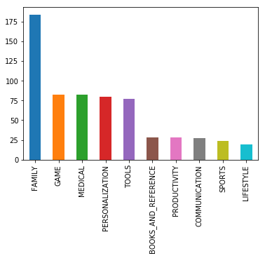

```python
#Premium Apps By Category
df_paid_apps.Category.value_counts()[:10].plot('bar')
```

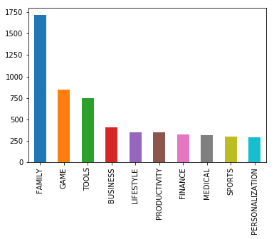

```python
#Freemium Apps By Category
df_free_apps.Category.value_counts()[:10].plot('bar')
```

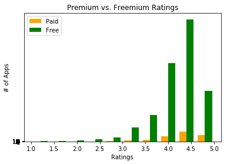

```python
#comapre free vs paid rating
score_premium = df[df.Type == 'Paid']['Rating']
score_freemium = df[df.Type == 'Free']['Rating']

plt.hist([score_premium, score_freemium], color=['orange', 'green'])
plt.xlabel("Ratings")
plt.ylabel("# of Apps")
plt.legend(['Paid', 'Free'])

plt.yticks(range(1, 20))
plt.title('Premium vs. Freemium Ratings')
plt.show()
```

> The average rating for paid apps and free apps have a similar curve

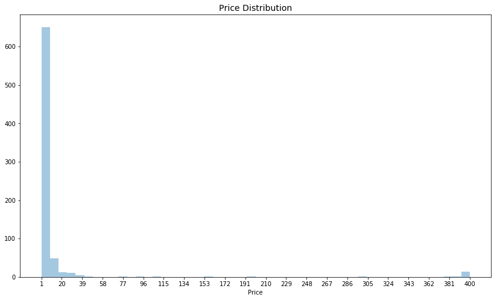

```python
#plot price distribution
plt.figure(figsize=(14,8))

sns.distplot(df_paid_apps["Price"],kde=False)
plt.xticks(np.arange(min(df_paid_apps["Price"]), max(df_paid_apps["Price"])+1, 19.0))
plt.title('Price Distribution',size = 14)

plt.show()
```